# Input Uncertainty in Simulation Analytics

## Introduction

- Network of three consecutive M/M/1 queues, where final node undergoes breakdown (maintenance?)
- Input parameters are arrival rate (Poisson), and three service rates (exponential).
- Intervals between breakdown are constant, as is the time needed to repair.
- State data measures whether each server is busy, the number in each queue, and whether there is a breakdown at the final node for each arrival.
- Output data measures the time in the system.
- Classify whether time in system will be above/below some threshold for each arrival.

## Estimated Parameters

- True arrival rate is 4, and true service rates are 6, 8, 6.
- Estimate input parameters using maximum likelihood estimation on 500 observations each.
- Breakdown intervals are 100 time periods, with 5 time periods required to repair.
- Run simulation for 2000 time periods.
- Record state and output data, discard first 100 observations as burn-in
- Use threshold of 2.5 to classify time in the system.
- Total of 8429 observations, approximately 28.2% above threshold.

### Baseline Model

- Create a baseline model that classifies all results as 1 and measure the F1 score.

```
## Baseline F1 score: 0.4404
```

### Logistic Regression Model

- Test the performance of a logistic regression model across the whole dataset.
- We use cross-validation with 5-folds.
- Note we shuffle the data as the ordering is not arbitrary.

```
## 0.8280 F1 score with a standard deviation of 0.006
```

- Logistic regression clearly outperforms the baseline model.
- We fit a logistic regression model to the whole dataset to produce our final predictive model.

## Performance at True Parameters

- We want to learn how this model performs on simulation data driven by the true parameters.
- Firstly, run the simulation model using the estimated parameters (MLEs) 100 times.
- Test the final classification model on these datasets to learn about the variability in F1 scores.

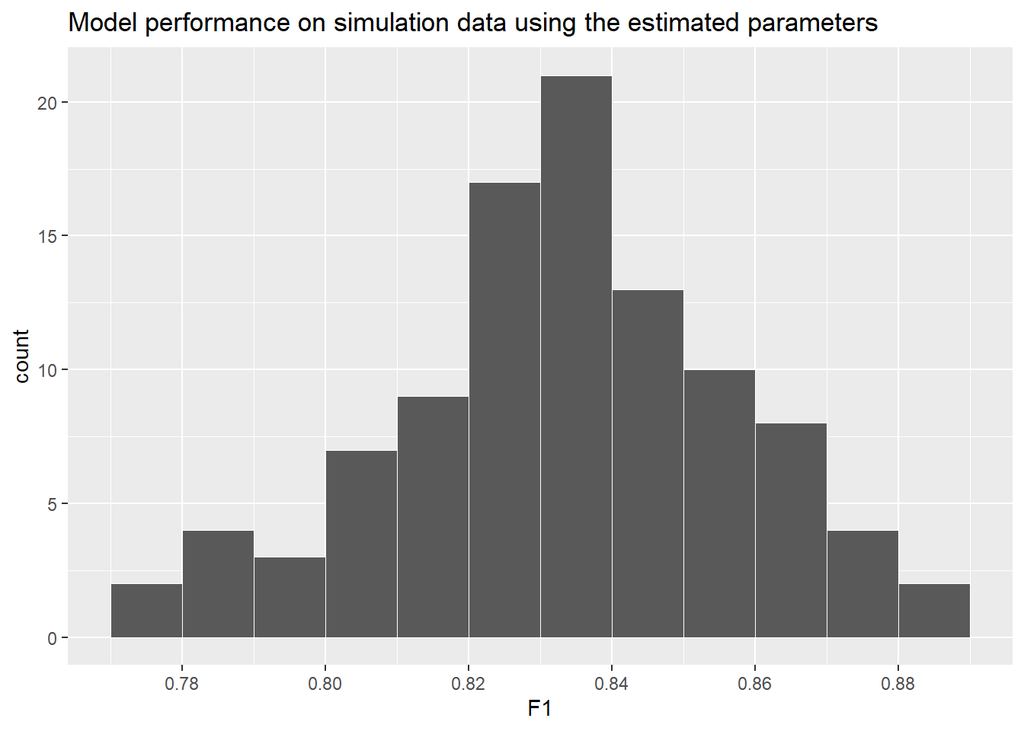

- Now run the simulation model 100 times using the true parameters.
- Compute the F1 score of our classification model on each simulation data set.
- Compare performance of model on estimated parameters simulation data and true parameter simulation data.

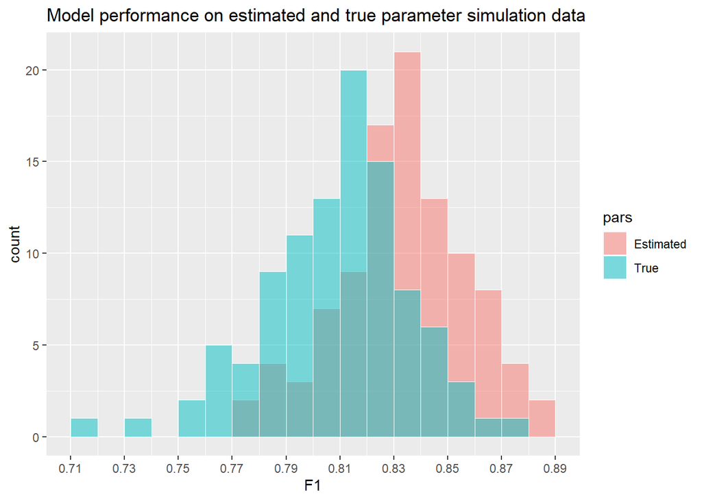

### Hypothesis Test

- Hypothesis test to see whether there is a difference in model performance on simulation data from the estimated parameters versus simulation data from the true parameters.
- Null hypothesis is that the two independent samples have the same mean, and alternative hypothesis is that they don’t.
- Use a two sample z-test, substituting the sample variances for the unknown population variances.

```
##
##  Two-sample z-Test
##
## data:  MLE_f1s$F1 and true_f1s$F1
## z = 6.6472, p-value = 2.987e-11
## alternative hypothesis: true difference in means is not equal to 0
## 95 percent confidence interval:
##  0.01702812 0.03126867
## sample estimates:
## mean of x mean of y
## 0.8326478 0.8084994
```

- Very small p-value suggests there a significant difference in performance.
- Decrease in performance under the true parameters, do we technically need to do a one-tailed test to determine this?

## Experimental Design

- True parameters are unknown, so consider how the model performs over some range of parameter values, determined by the input data.
- Estimate parameter variance using observed Fisher information.
- Use a full factorial design over the four input parameters.
- Set upper and lower levels as MLEs plus/minus one standard deviation.
- Run simulation using each design point 100 times, and measure performance of classification model.

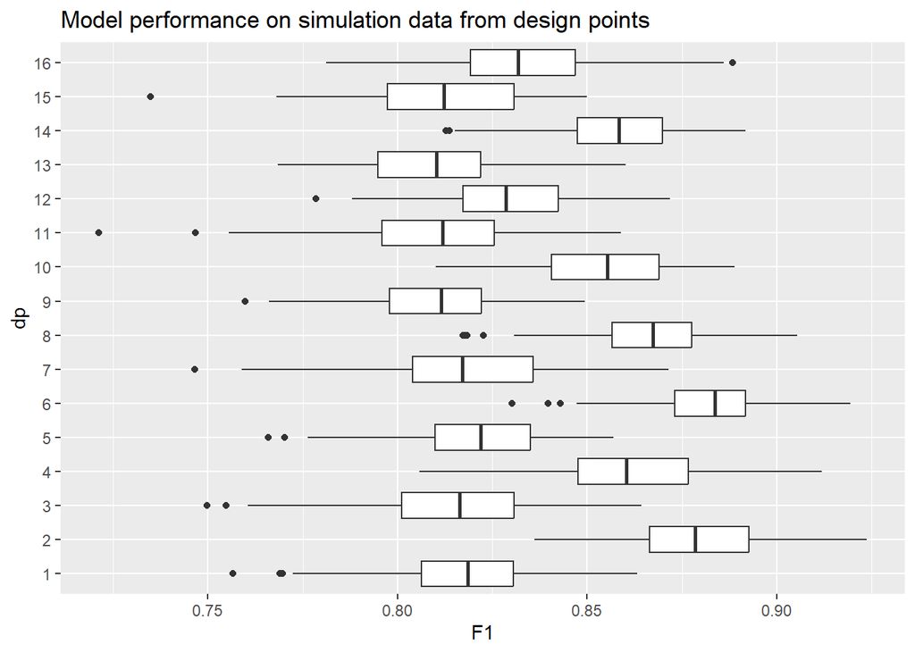

- Run hypothesis test at each design point.
- Tabulate design points, with mean and standard devation of F1 scores, and p-value.

```
##       lambda   mu1   mu2   mu3 mean_F1 sd_F1 p-value
##  [1,]  4.101 5.492 7.795 5.536   0.817 0.021   0.000
##  [2,]  4.486 5.492 7.795 5.536   0.880 0.019   0.000
##  [3,]  4.101 6.006 7.795 5.536   0.816 0.023   0.000
##  [4,]  4.486 6.006 7.795 5.536   0.860 0.020   0.000
##  [5,]  4.101 5.492 8.525 5.536   0.820 0.020   0.000
##  [6,]  4.486 5.492 8.525 5.536   0.882 0.018   0.000
##  [7,]  4.101 6.006 8.525 5.536   0.818 0.024   0.000
##  [8,]  4.486 6.006 8.525 5.536   0.865 0.018   0.000
##  [9,]  4.101 5.492 7.795 6.054   0.811 0.019   0.000
## [10,]  4.486 5.492 7.795 6.054   0.855 0.019   0.000
## [11,]  4.101 6.006 7.795 6.054   0.809 0.026   0.000
## [12,]  4.486 6.006 7.795 6.054   0.829 0.019   0.272
## [13,]  4.101 5.492 8.525 6.054   0.810 0.020   0.000
## [14,]  4.486 5.492 8.525 6.054   0.857 0.019   0.000
## [15,]  4.101 6.006 8.525 6.054   0.812 0.022   0.000
## [16,]  4.486 6.006 8.525 6.054   0.834 0.021   0.747
```

- 14 design points with very small p-values, indicating significant difference in model performance.
- 2 design points where model performance is similar to that on the MLE simulation data.
- Fit linear regression model using input parameter values as predictor variables, and mean F1 score as the response.
- Test model with and without interaction terms.

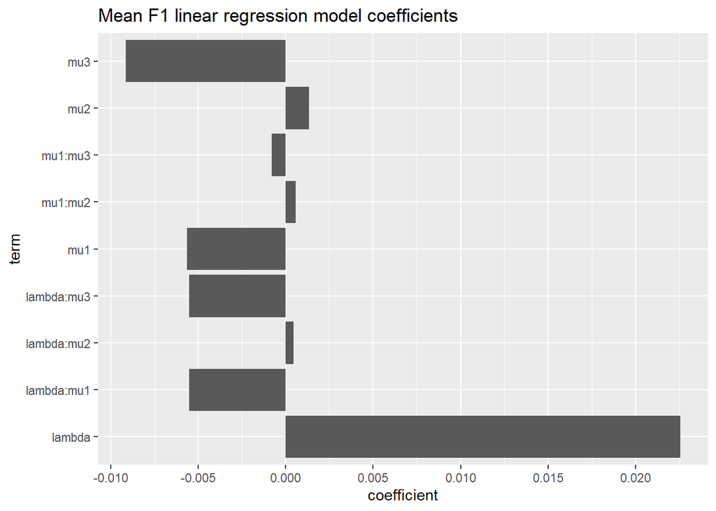

- Interaction model has an R-squared score of 0.998.
- Lambda has the largest coefficient by a fair way, followed by mu3, and then mu1, lambda:mu1 and lambda:mu3 which are all similar size.
- Model without interaction terms has an R-squared score of 0.913.

### Comparison to Mean Output

- Fit a linear regression model using input parameter values as predictor variables, and the mean simulation output as the response.

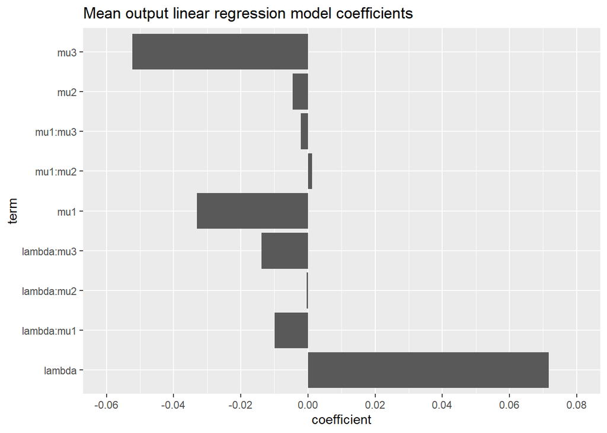